# How to Mizer - how to calibrate/refine a mizer model to time-averaged catch data

Julia L. Blanchard, Ken H. Andersen, Gustav Delius, Romain Forestier

2021-06-09

# Intermediate level tutorial - how to calibrate a Mizer model

In this tutorial you will learn

- How to refine key parameters using optimization so the model is in the right ballpark as the data
- Simple calibration protocol - shown sequentially for `R_max`, `erepro` and `kappa`
- Introduce rShiny for model exploration

In this tutorial, we are going to follow the same path as HTM1 and keep using the North Sea data set as an example.

We finished HTM1 with a manually parametrised model with species coexisting, now we want our model to reflect reality. To do so we are going to compare the model output to data by matching catch, biomass and/or growth rate depending on what is available.

In the plot below we compare the catch output of the model and the averaged catch we extracted from the ICES database in the previous tutorial using the function `plotPredObsYield`. This is going to be our main comparison used to calibrate the model towards more real life behavior.

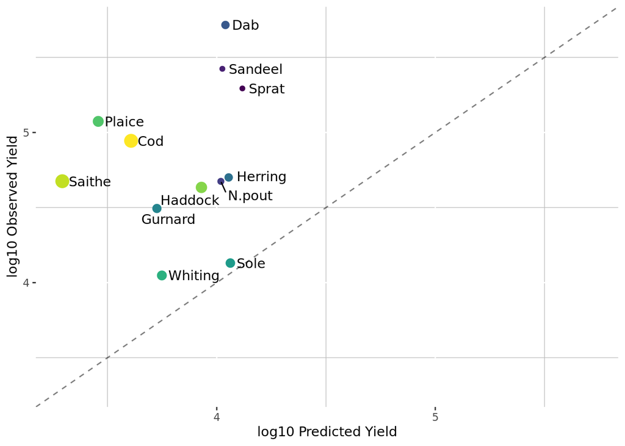

At the moment, the observed yield are higher than the predicted yield for all species. We want them to be equal (on the diagonal).

## Step 1. Calibrate the maximum recruitment

In this section you will:

- use a package that will calibrate `R_max` per species

`R_max` affects the relative biomass of each species (and, combined with the fishing parameters, the catches). We are going to change with the aim of minimising the error between observed and estimated catches or biomasses. Both `erepro` and `kappa` affect the relative biomass of each species and can be used (as in Blanchard et al. 2014 & Spence et al. 2016) but for now we are going to keep them at default value and focus on `R_max` only.

First let’s set up a function running the model and outputing the difference between predicted catches (`getYield()`) and actual catches (`catchAvg`). `getError()` outputs the sum of squared errors between the two.

```r
# we need 12 Rmaxs, log10 scale
vary <- log10(params_guessed@species_params$R_max)
## test it
getError(vary = vary, params = params_guessed, dat = catchAvg$Catch_1419_tonnes)
```

```
## Convergence was achieved in 103.5 years.
```

```
## [1] 77.34717
```

Now, carry out the optimisation. There are several optimisation methods to choose from - we need to select the most robust one to share here. The R package `optimParallel` seems to be the most robust general R package and has replaced optim. Often this requires repeating the procedure several times but the advantage of using parallel run is the speed compared to packages such as optimx.

This might take AWHILE. The output is saved as `optimParallel_Rmax.RDS` if you wish to skip this block.

```r
# create set of params for the optimisation process
params_optim <- params_guessed
vary <-  log10(params_optim@species_params$R_max) # variable to explore
params_optim<-setParams(params_optim)
# set up workers
noCores <- detectCores() - 1 # keep some spare core
cl <- makeCluster(noCores, setup_timeout = 0.5)
setDefaultCluster(cl = cl)
clusterExport(cl, as.list(ls()))
clusterEvalQ(cl, {
  library(mizerExperimental)
  library(optimParallel)
})
optim_result <-optimParallel(par=vary,getError,params=params_optim, dat = catchAvg$Catch_1419_tonnes, method   ="L-BFGS-B",lower=c(rep(3,12)),upper= c(rep(15,12)),
                            parallel=list(loginfo=TRUE, forward=TRUE))
stopCluster(cl)
saveRDS(optim_result,"optimParallel_Rmax1.RDS")
```

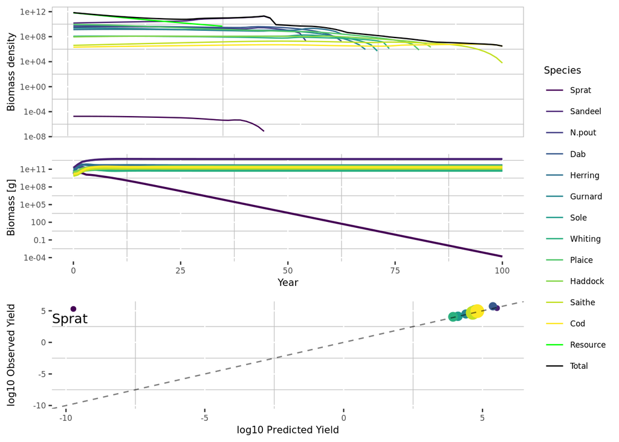

```r
# if previous block was not evaluated
params_optim <- params_guessed
optim_result <- readRDS("optimParallel_Rmax1.RDS")
# optim values:
params_optim@species_params$R_max <- 10^optim_result$par
params_optim <-setParams(params_optim)
sim_optim <- project(params_optim, effort = 1, t_max = 100, dt=0.1,initial_n = sim_guessed@n[100,,],initial_n_pp = sim_guessed@n_pp[100,])
saveRDS(sim_optim,"sim_optim1.RDS")
plotCalibration(sim_optim,catch_dat = catchAvg$Catch_1419_tonnes )
```

Calibrating for best observed/predicted yield makes one species (Sprat) show signs of collapse. We need to look at other parameters to get the community to coexist again.

## Step 2. Calibrate the recruitment with erepro.

In this section you will:

- Look at effect of `erepro` on the reproductive outputs
- Check what impact `erepro` has on the $F_{msy}$

`erepro` represents the energy conversion efficiency between energy allocated to reproduction and the actual spawn. Lowering `erepro` biologically means higher egg mortality rate or wasteful energy invested into gonads. For example, `erepro` is currently set to $0.01$ meaning, that for every one $g$ of mass allocated to reproduction, $0.01g$ will be used as spawn recruitment, the rest is lost. This coefficient is applied before any density-dependence requirement. Let’s use Rshiny to see how varying `erepro` influences the ecosystem (to play around).

> Rshiny app erepro

A good indicator of realistic `erepro` value is the shape of the fishing mortality rate versus yield curve. Such graph allows to determine the fisheries maximum sustainbale yield when harvesting a species and is supposed to have a bell shape. Too high fishing mortality depletes the stock and reduce the yield whereas too low fishing mortality simply means low yield. The $F_{msy}$ sits in the middle, at the top of the bell. If a species is too reproduction efficient and can replenish its biomass even under high fisheries mortality, its `erepro` is too high. Conversely, if a low fisheries mortality depletes the stock right away, the species’ `erepro` is too low.

Let’s take a look at the current $F_{msy}$ per species.

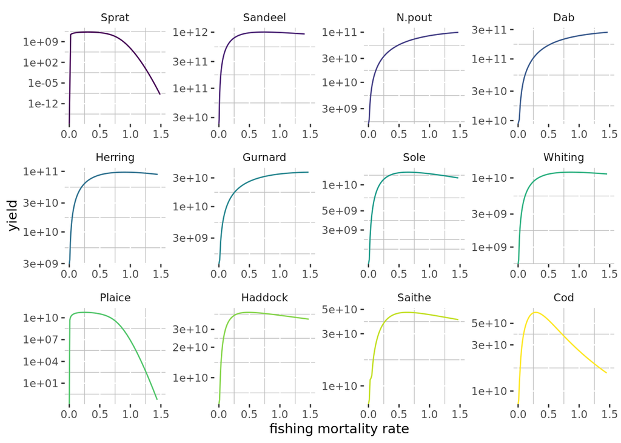

Decreasing `erepro` is going to move the $F_{msy}$ towards lower effort. Until now we had the same `erepro` for all species but we can input species-specific values to calibrate our recruitment. To do so, let’s use another shiny app again. The next one allows you to change `erepro` one at a time and see the effect on the species’ $F_{msy}$

> Rshiny app Fmsy Note: the shiny app only calculate the $F_{msy}$ of one species at a time (for speed reasons) and the final results may not be exactly the same as calculating the $F_{msy}$ for every species together (as shown below)

Let’s see what our system looks like with species-specific `erepro`

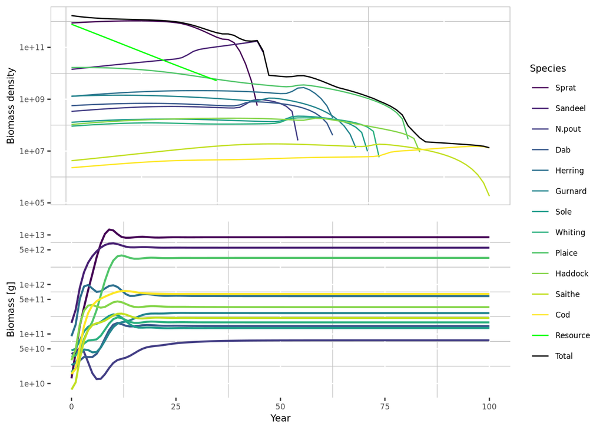

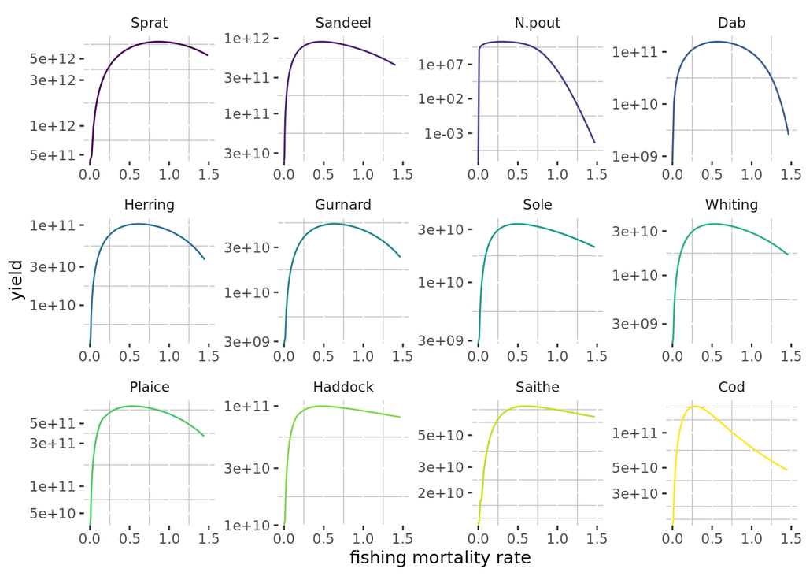

```r
sim_optim <- readRDS("sim_optim1.RDS")
params_optim <- sim_optim@params # redundancy if previous blocks were not run
params_optim@species_params$erepro <- 10^(c(-1.7,-3.2,-4,-4,-3,-3.5,-3.5,-4.1,-2.7,-3,-2.5,-1.7))
params_optim2 <- setParams(params_optim)
sim_optim2 <- project(params_optim2, effort = 1, t_max = 100)
saveRDS(sim_optim2, file = "sim_optim2.RDS")
```

Some trade-offs here, relatively high `erepro` allows Sprat to coexist with the other species but the $F_{msy}$ plot doesn’t have the characteristic bell shape. Here Sprat is too efficient and survive even at high fisheries mortality. Note that the curve could start to go down at higher fisheries mortality.

Before spending more tome hand tweaking these species, we are going to run the `R_max` calibration again to see if we improved the yield match (as in step 1).

```r
# looping calibration to get more accurate results
sim_loop <- readRDS(file = "sim_optim2.RDS")
params_loop <- sim_loop@params
for(i in 1:5)
{
# saving the last time step in the param object
params_loop@initial_n <- sim_loop@n[dim(sim_loop@n)[1],,]
params_loop@initial_n_pp <- sim_loop@n_pp[dim(sim_loop@n_pp)[1],]
params_calibration <- params_loop
vary <-  log10(params_calibration@species_params$R_max)
params_calibration<-setParams(params_calibration)
noCores <- detectCores() - 1 # keep a spare core
cl <- makeCluster(noCores, setup_timeout = 0.5)
setDefaultCluster(cl = cl)
clusterExport(cl, as.list(ls()))
clusterEvalQ(cl, {
  library(mizerExperimental)
  library(optimParallel)
})
optim_loop <-optimParallel(par=vary,getError,params=params_calibration, dat = catchAvg$Catch_1419_tonnes,
                             method   ="L-BFGS-B",lower=c(rep(3,12)),upper= c(rep(15,12)),
                            parallel=list(loginfo=TRUE, forward=TRUE))
stopCluster(cl)

# optim values:
params_loop@species_params$R_max <- 10^optim_loop$par
# set the param object
params_loop <-setParams(params_loop)
sim_loop <- project(params_loop, effort = 1, t_max = 100, dt=0.1, initial_n = params_loop@initial_n ,
                      initial_n_pp = params_loop@initial_n_pp)
}
saveRDS(optim_loop,"optimParallel_Rmax2.RDS")
```

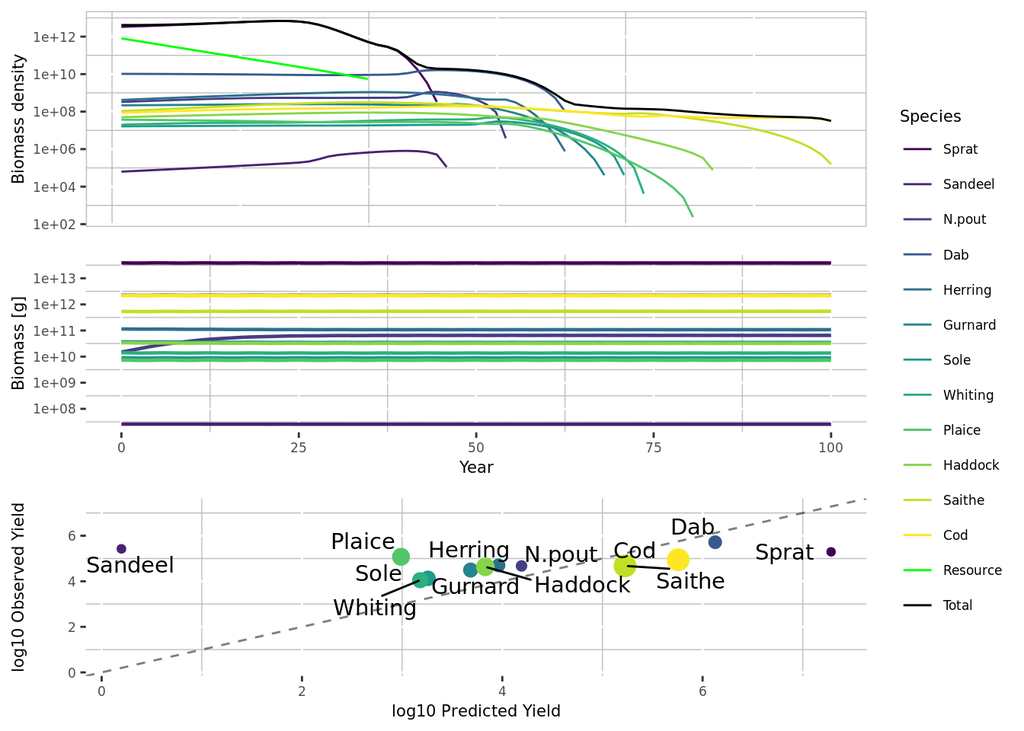

```r
# running sim a bit longer before saving it
sim_loop <- project(params_loop, effort = 1, t_max = 300)
params_loop@initial_n <- sim_loop@n[dim(sim_loop@n)[1],,]
params_loop@initial_n_pp <- sim_loop@n_pp[dim(sim_loop@n_pp)[1],]
sim_loop <- project(params_loop, effort = 1)
saveRDS(sim_loop,"sim_optim3.RDS")
```

## Step 3. Calibrating the growth

In this section you will:

- Look at the growth curves of each species
- Tweak the `kappa` parameter to adjust the growth curves of all species at once
- Tweak the `gamma` parameter to adjust the growth curve species by species

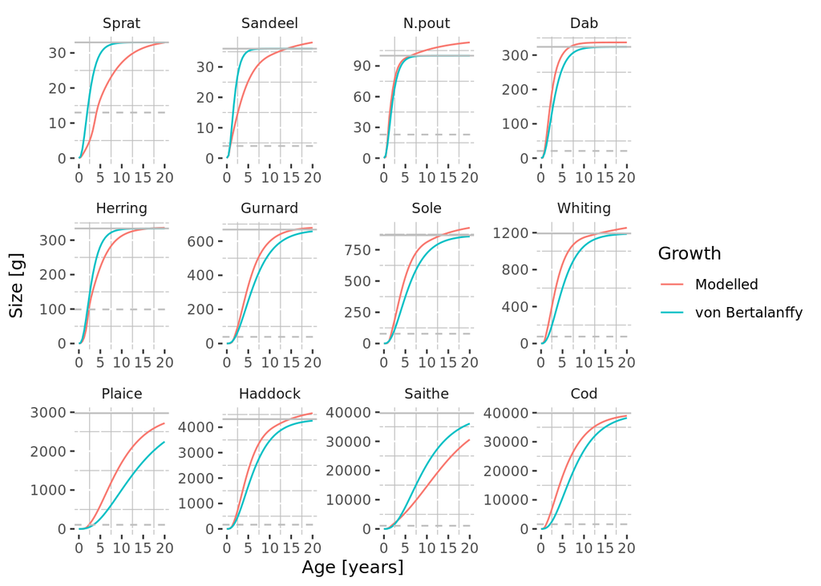

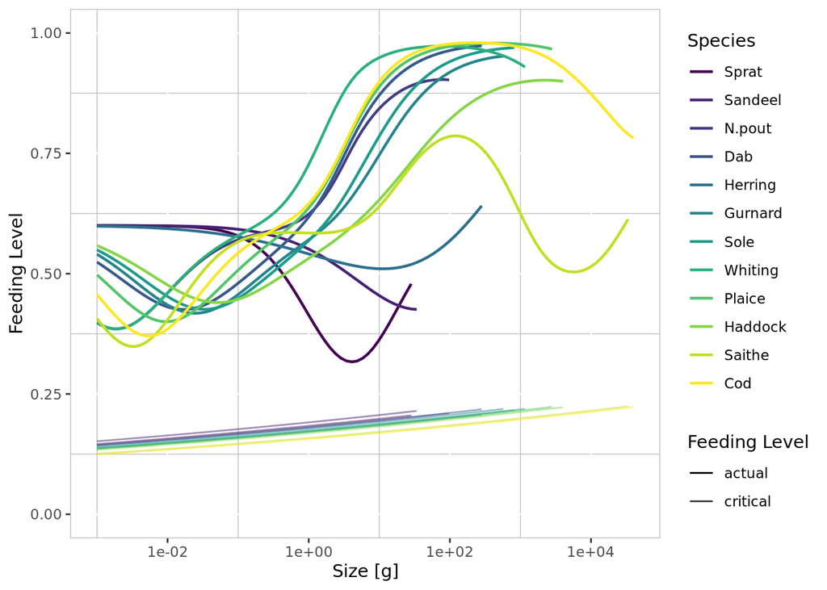

The feeding level here shows that the species reaching the highest size classes have a feeding level close to one, meaning that they feed to satiation. Let’s look at their diet to check what makes them to full.

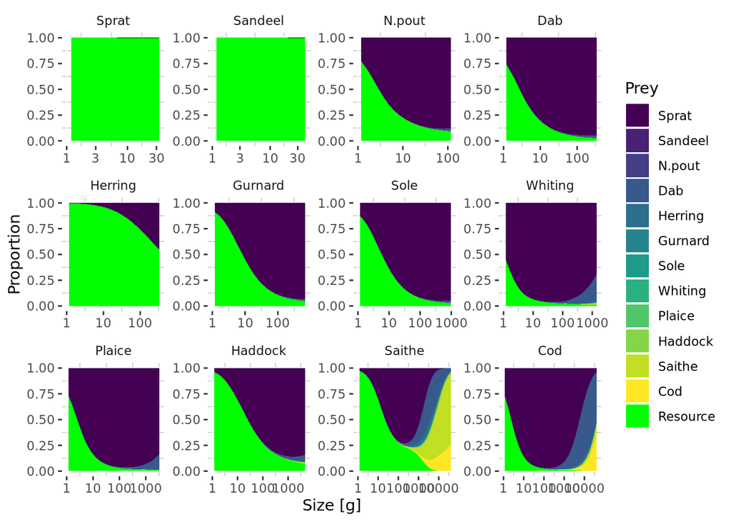

The diets look great as the fish feed on each other and do not rely too much on the background spectrum. We can still reduce the carrying capacity of the background spectrum even more, which could lower the feeding level of the species. Let’s do this using the Rshiny app

> Rshiny app kappa

Decreasing slightly `kappa` drives Sprat to extinction probably as it becomes the next choice of food when we reduce the size of the background spectrum (as we saw on the diet plots). So how can we reduce the feeding level of the largest predators while keeping Sprat alive?

> Rshiny app gamma

Let’s input the new gamma value in a new set of parameters

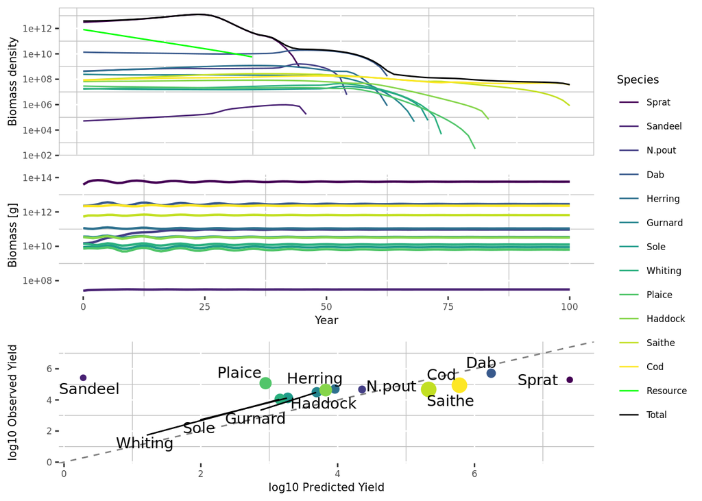

```r
newGamma <- c(1.100000e-10, 6.000000e-11, 9.910525e-11, 7.707098e-11, 2.556902e-11, 4.717030e-11,
              5.272039e-11, 1.009092e-10, 4.565019e-11, 7.837794e-11, 4.000000e-10, 2.365167e-10)

params_growth <- sim_loop@params
params_growth@species_params$gamma <- newGamma
params_growth <- setParams(params_growth)
sim_growth <- project(params_growth, effort = 1, t_max = 100)

plotCalibration(sim_growth, catch_dat = catchAvg$Catch_1419_tonnes)
```

Small oscillations but the species stabilise again.

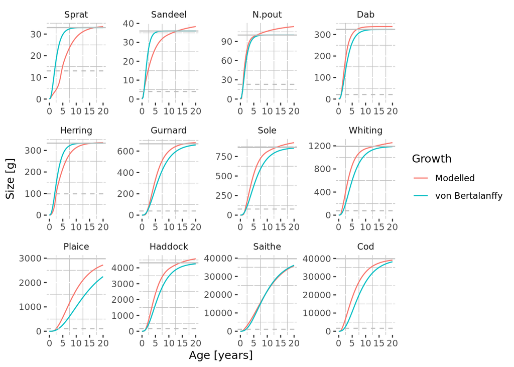

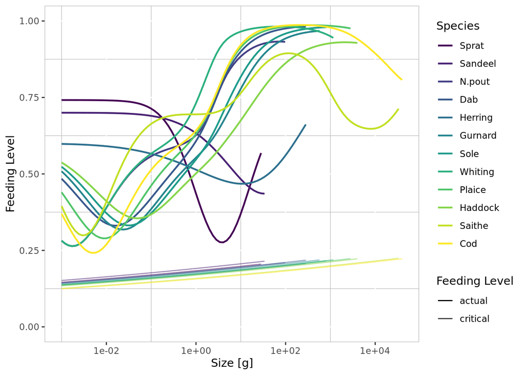

Growth curves haven’t change much but the feeding level has decreased at small size (even if we theoretically increase the feeding of the small species, maybe they are now too good competitor for the other species and steal their food)

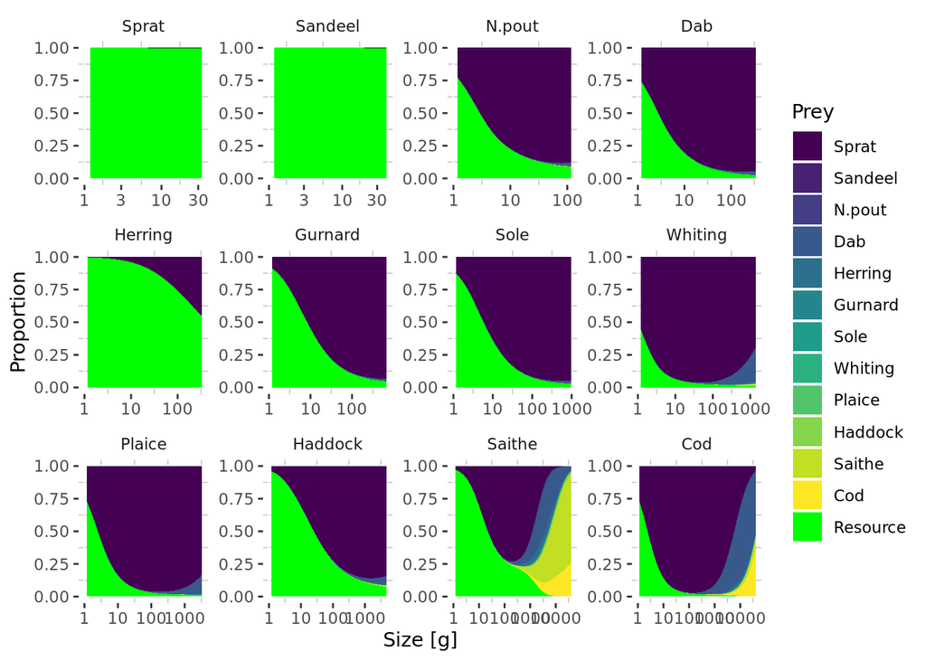

One will note that changing the the search volume of some species did not affect the diet. Therefore `gamma` doesn’t influence the diet proportion.